# Teste Nuvemshop

```python
import matplotlib.pyplot as plt
%matplotlib inline
import pandas as pd
import numpy as np
import geocoder
import plotly.express as px
from scipy import stats
pd.set_option('display.max_columns', None)
```

## Importando e tratando dados

```python
df = pd.read_excel('Exercicio_1 - datos-trials-may17-BR.xlsx')
```

### Corrigir encoding do arquivo

```python
def encode(s):
    if isinstance(s, str):
        return s.encode('iso-8859-1', 'backslashreplace').decode('utf-8', 'backslashreplace')
    else:
        return s
df['city'] = df['city'].apply(lambda x: encode(x))
df['region'] = df['region'].apply(lambda x: encode(x))
```

### Agrupar operadoras

```python
def carrier_normalize(carrier):
    if not isinstance(carrier, str):
        return carrier
    carrier_list = ['TIM', 'Claro', 'Porto Conecta', 'Algar']
    for c in carrier_list:
        if c.lower() in carrier.lower():
            return c

    return carrier

df['carrier_group'] = df['carrier'].apply(lambda x: carrier_normalize(x))
```

## Análises

### Acessos por operadora de telefonia

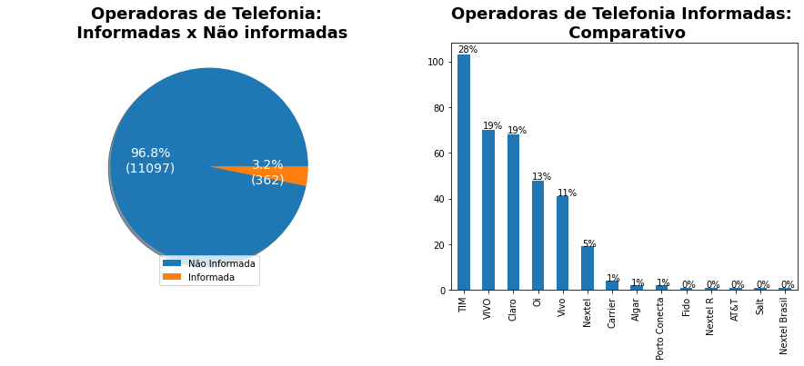

```python
def func_label(pct, allvals):
    absolute = int(pct/100.*np.sum(allvals))
    return "{:.1f}%\n({:d})".format(pct, absolute)

carrier_blank = df[pd.isna(df['carrier'])].shape[0]
dados_1 = pd.DataFrame(
    {'total': [carrier_blank, df.shape[0] - carrier_blank]},
    index = ['Não Informada', 'Informada']
)
fig, axes = plt.subplots(figsize=(15,5), nrows=1,ncols=2)
dados_1.plot(
    ax = axes[0], kind='pie', subplots=True, fontsize=14,
    autopct=lambda pct: func_label(pct, dados_1),
    textprops=dict(color="w"),
    shadow=True
)
axes[0].legend(loc='lower center')
axes[0].set_title('Operadoras de Telefonia: \n Informadas x Não informadas', fontdict={'fontsize':18, 'fontweight':'bold'})
axes[0].set_ylabel(None)
axes[0].set_xlabel(None)

dados_2 = df['carrier_group'].value_counts(dropna=True)
dados_2.plot(
    ax = axes[1],
    kind='bar'
)
axes[1].set_title('Operadoras de Telefonia Informadas: \n Comparativo', fontdict={'fontsize':18, 'fontweight':'bold'})



for p in axes[1].patches:
    text = '{:.0f}%'.format(p.get_height() / dados_2.sum() * 100)
    axes[1].annotate(text, (p.get_x() * 1.005, p.get_height() * 1.010))
```

### Acesso por região

```python
def get_geo(x):
    g = geocoder.osm(x)
    if g:
        return g.lat, g.lng
    else:
        return None, None

cidades = df['region'].value_counts(dropna=True).to_frame()
cidades.columns = ['qtd']
cidades['region'] = cidades.index
cidades['geo'] = cidades['region'].apply(lambda x: get_geo(x))
cidades['lat'] = cidades['geo'].apply(lambda x: x[0])
cidades['lng'] = cidades['geo'].apply(lambda x: x[1])
```

```python
fig = px.scatter_mapbox(
    cidades, lat="lat", lon='lng',
    hover_name="region", size="qtd",
    zoom=2, height=600
)
fig.update_layout(mapbox_style="open-street-map")
fig.update_layout(margin={"r":0,"t":0,"l":0,"b":0})
fig.show()
```

[interactive chart not shown]

### Data de entrada

Podemos observar que a entrada de novos clientes é mais acentuada as segundas, terças e quartas-feiras. As campanhas de marketing estão mais centralizadas nesses dias? Ou os potenciais clientes estão mais dispostos a iniciar o trial no início da semana? É interessante descobrir o mecanismo que acarreta esse comportamento pois o mesmo pode potencializar as ações de marketing.

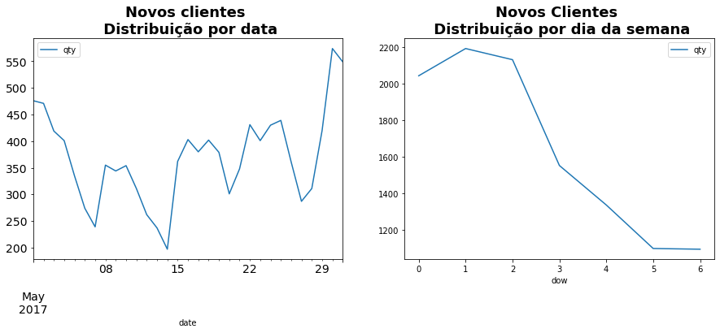

```python
# agrupando por dia de entrada
df_date = df['gp:created_at'].value_counts().to_frame()
df_date['date'] = df_date.index
df_date.sort_values(by='date', inplace=True)
df_date.columns = ['qty',  'date']

# removendo outliers
df_date = df_date[np.abs(stats.zscore(df_date['qty'])) < 2.5]

# dia de semana
df_date['dow'] = df_date['date'].apply(lambda x: x.weekday())



fig, axes = plt.subplots(figsize=(15,5), nrows=1,ncols=2)
df_date.plot(
    ax = axes[0], kind='line', subplots=True, fontsize=14,
    x='date', y='qty'
)
axes[0].set_title('Novos clientes \n Distribuição por data', fontdict={'fontsize':18, 'fontweight':'bold'})

df_dow = df_date.groupby('dow').sum()
df_dow.plot(
    ax = axes[1],
    kind='line'
)
axes[1].set_title('Novos Clientes \n Distribuição por dia da semana', fontdict={'fontsize':18, 'fontweight':'bold'})
```

### Linguagem do usuário

- Mais de 97% dos clientes são de língua portuguesa. Internacionalização do sistema não parece algo crítico no momento, embora uma expansão seja sempre interessante de ser avaliada.

```python
df_language = df['language'].value_counts().to_frame()
df_language.columns = ['qty']
df_language['fr'] = df_language['qty'] / df_language['qty'].sum() * 100
df_language.round(2)
```

|  | qty | fr |
| --- | --- | --- |
| Portuguese | 10901 | 97.61 |
| English | 223 | 2.00 |
| Spanish | 33 | 0.30 |
| Italian | 2 | 0.02 |
| French | 2 | 0.02 |
| Dutch | 2 | 0.02 |
| Turkish | 1 | 0.01 |
| Arabic | 1 | 0.01 |
| Russian | 1 | 0.01 |
| Chinese | 1 | 0.01 |
| Japanese | 1 | 0.01 |

### Como chegou à loja

Boa parte dos novos clientes chegam à loja por anúncios do google. Uma análise interessante seria cruzar esses dados com o valor gasto em cada uma das campanhas a fim de medir sua efetividade

[figure not shown]

```python
df_utm_source = df['gp:initial_utm_source'].value_counts()
fig = df_source.plot(kind='bar', figsize=(10,5))

for p in fig.patches:
    text = '{:.0f}%'.format(p.get_height() / df_utm_source.sum() * 100)
    fig.annotate(text, (p.get_x() * 1.005, p.get_height() * 1.010))
```

### Plataforma de acesso

- 47% dos usuários acessam a plataforma pelo desktop
- 49% utilizam o android

Essas informações podem ser relevantes na hora de direcionar testes de software ou o desenvolvimento de novas features.

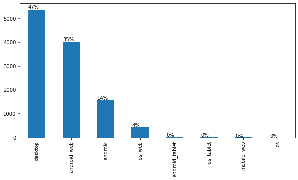

```python
df_source = df['gp:source'].value_counts()
fig = df_source.plot(kind='bar', figsize=(10,5))

for p in fig.patches:
    text = '{:.0f}%'.format(p.get_height() / df_source.sum() * 100)
    fig.annotate(text, (p.get_x() * 1.005, p.get_height() * 1.010))
```

### Vertical

O campo gp:vertical parece ser o segmento da loja

- O segmento Outros corresponde a 30% de toda a base. Merece ser melhor investigado e intendido.
- O segmento Clothing corresponde a 29% da base. A informação pode ajudar a direcionar o desenvolvimento de novas features e também campanhas de marketing.

Outra análise possível é cruzar essa distribuição de segmentos com as demais lojas virtuais presentes na web. Discrepâncias podem sugerir para quais segmentos a NuvemShop é mais ou menos atrativa e/ou identificar possíveis nichos de mercado ainda inexplorados.

[figure not shown]

```python
df_vertical = df['gp:vertical'].value_counts()
fig = df_source.plot(kind='bar', figsize=(10,5))

for p in fig.patches:
    text = '{:.0f}%'.format(p.get_height() / df_vertical.sum() * 100)
    fig.annotate(text, (p.get_x() * 1.005, p.get_height() * 1.010))
```